# Unified theory of growth

**NOTE**: The present notebook is coded in R. It relies heavily on the [**tidyverse**](https://www.tidyverse.org/) ecosystem of packages. We load the tidyverse below as a prerequisite for the rest of the notebook - along with a few other libraries.

$\rightarrow$ Don’t forget that code flows **sequentially**. A random chunk may not work if the previous have have not been executed.

```r
library(tidyverse)   # Package for data wrangling
library(readxl)      # Package to import MS Excel files
library(latex2exp)   # Package for LaTeX expressions
library(quantmod)    # Package for stock data extraction
library(highcharter) # Package for reactive plots
```

The content of the notebook is heavily inspired from the book [**Advanced Macro-economics - An Easy Guide**](https://press.lse.ac.uk/site/books/m/10.31389/lsepress.ame/).

# Context

In physics, scientists have tried for decades to build a [**theory of everything**](https://en.wikipedia.org/wiki/Theory_of_everything). There are two theories:

- **quantum mechanics**, which tries to explain what happens at very small scales (sub-atomic) - it is based on the strong nuclear, weak nuclear, and electromagnetic forces;
- **general relativity**, which seeks to explain what drives stellar bodies at very large scales (based on gravity mostly)

$\rightarrow$ But **reconciling the two is incredibly hard**.

Here the aim is similar, but for economics. Indeed, we have sought to study models that could explain the post-industrial revolution growth.

At the same time, if a model wants to be exhaustive, it should also explain the centuries of stagnation that occurred before the 18th century (Malthusian stagnation).

# The model

## Production and utility

We start with the production function

$$Y_t=H_t^a(A_tX)^{1-a},$$

where $H_t$ is the (total) efficiency of labor, $A_t$ is **productivity** and $X$ is the **land** used for production (assumed to be constant…). If we divide by labor $L_t$, with $x_t=A_tX/L_t$,
$$y_t=h_t^ax_t^{1-a}.$$

**Utility** is defined as
$$u_t=c_t^{1-\gamma}(n_th_{t+1})^\gamma, \tag{1}$$
with $c_t$ being consumption, $n_t$ the number of children and $h_{t+1}$ their future efficiency (or “*quality*”). This idea comes from the premise that parents will care about their children’s education (and well-being of course).

The constraint of the model is built as follows. The **consumption** of households is bound by **income**, a baseline wage $w_t$ times quality $h_t$ (imagine that better trained individuals earn more for instance).

However, the total time dedicated to work is split between a unit of time, minus the number of children multiplied by the average time required to raise one child $\tau$ plus a potential additional effort if the parent wants to increase $h_{t+1}$ for the offspring; this effort is $e_{t+1}$. The (saturated) constraint is then
$$c_t=w_th_t(1-\underbrace{n_t(\tau+e_{t+1})}_{\text{time for kids}}). \tag{2}$$
Basically, potential income $w_th_t$ is split between consumption - or raising children.

**Human capital** is a function of two components:
$$h_{t+1}=h(e_{t+1}, g_{t+1}), \tag{3}$$
where $g_{t+1}=A_{t+1}/A_t-1$ is the **rate of technological progress** and $e_{t+1}$ is the effort put into **education**.

## Solution

We plug the consumption value Equation 2 and human capital Equation 3 in Equation 1:
$$u_t= (w_th_t(1-n_t(\tau+e_{t+1})))^{1-\gamma}(n_t h(e_{t+1}, g_{t+1}))^\gamma$$

Parents optimize their utility by chosing the number of children $n_t$ and the intensity of education $e_{t+1}$. We have
$$\begin{align}
\frac{\partial u_t}{\partial n_t}=-(1-\gamma)(\tau+e_{t+1}) w_th_t (w_th_t(1-n_t(\tau+e_{t+1})))^{-\gamma}(n_t h(e_{t+1}, g_{t+1}))^\gamma \\ +\gamma n_t^{\gamma-1}(w_th_t(1-n_t(\tau+e_{t+1})))^{1-\gamma} h(e_{t+1}, g_{t+1})^\gamma
\end{align}$$

Hence the FOC for $n_t$ is

$$(1-\gamma)(\tau+e_{t+1})w_th_t=\gamma n_t^{-1} w_th_t(1-n_t(\tau+e_{t+1}))$$

i.e., given the definition of $c_t$ in Equation 2,
$$\frac{1-\gamma}{\gamma}(\tau+e_{t+1})w_th_t=\frac{c_t}{n_t} \quad \Leftrightarrow \quad \frac{c_t}{w_th_t}=n_t \frac{1-\gamma}{\gamma}(\tau+e_{t+1}) \tag{4}$$

But from Equation 2, $c_t/(w_th_t)=(1-n_t(\tau+e_{t+1}))$, hence

$$1-n_t(\tau+e_{t+1})=n_t \frac{1-\gamma}{\gamma}(\tau+e_{t+1}) \quad \Leftrightarrow \quad \gamma=n_t(\tau+e_{t+1}),$$
i.e., the parents will dedicate a proportion $\gamma$ to raising their child(ren).

Moreover, with respect to **education**, it holds that

$$\begin{align}\frac{\partial u_t}{\partial e_{t+1}}=-(1-\gamma)w_tn_th_t (w_th_t(1-n_t(\tau+e_{t+1})))^{-\gamma} (n_th(e_{t+1}, g_{t+1}))^\gamma \\ + \gamma n_t h_e(e_{t+1}, g_{t+1})(w_th_t(1-n_t(\tau+e_{t+1})))^{1-\gamma} (n_th(e_{t+1}, g_{t+1}))^{\gamma-1}
\end{align}$$

where $h_e$ is the derivative of *h* w.r.t. *e*. The FOC for education reduces to

$$(1-\gamma)w_tn_th_t =\gamma c_th_e(e_{t+1}, g_{t+1}) h(e_{t+1}, g_{t+1})^{-1}$$

i.e.,

$$\frac{1-\gamma}{\gamma h_e(e_{t+1}, g_{t+1})} n_t h(e_{t+1}, g_{t+1}) = \frac{c_t}{w_t h_t}$$

and plugging Equation 4, we get

$$\frac{1-\gamma}{\gamma h_e(e_{t+1}, g_{t+1})} n_t h(e_{t+1}, g_{t+1}) =n_t \frac{1-\gamma}{\gamma}(\tau+e_{t+1}) .$$

**Finally, we have**

$$\frac{h(e_{t+1}, g_{t+1})}{ h_e(e_{t+1}, g_{t+1})} =\tau+e_{t+1}.$$

A natural assumption is that *h* increases with *e* : **human capital benefits from education** $(h_e>0)$. This is required if we want to obtain $h>0$ in the above expression.

However, it also makes sense to consider that $h_g<0$ because **technology increases knowledge obsolescence**. Hence, parents will/should invest in education more when technology grows faster to limit the erosion of their child’s capabilities.

## Closing the loop

The interesting feature of the model is the interplay between technology, population and human capital (investment). These are, in the model: $n_t$ for **population growth** (via $n_t=L_{t+1}/L_t$), $e_t$ for **investment in education** and $g_t$ for **technological growth**. The latter has not formally been treated until now. We can make assumptions on $g:=g(e,L)$, that is: technological progress is driven by how much we invest in education (well trained work-force or R&D) and by the population size (more researchers imply more innovation - potentially).

From Equation 4, if the left-hand side is fixed, increasing quality via $\tau+e_{t+1}$ imposes to **reduce quantity** (for fixed $\gamma$), which is a feature observed in many developed countries since the beginning of the XXIst century (again: **demoagraphics** is **key**!). The transition from a Malthusian economy to sustainable growth is depicted below.

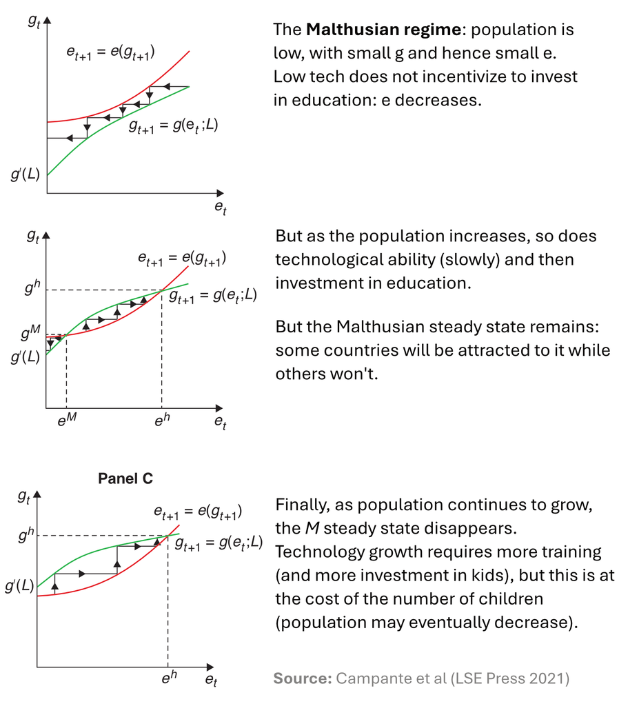

**Bottomline**

**Demographics** AND **technology** are key!